# Alice Ding

## knn model classification

```python
# for this type of model, we will be predicting whether the drama
# is classified as "romance" or not. to do this, we need to add a
# column in the data frame indicating whether or not this drama has
# 'romance' in its genres.

romance_tf = []
for genres in drama_df['genres']:
    curr = False
    if "Romance" in genres:
        curr = True
    romance_tf.append(curr)

# True = "Romance" exists, False if otherwise
drama_df['romance'] = romance_tf

y = drama_df['romance']
variables = ['rating', 'user_amount', 'ep_count',
             'review_amount', 'member_amount', 'actor_rating']
# creating testing & training data
X_train, X_test, y_train, y_test = train_test_split(
    drama_df[variables], y, test_size=0.3, random_state=1)

drama_df
```

|  | name | rating | description | year | ep_count | tags | genres | member_amount | review_amount | user_amount | actors | actor_rating | romance |
| --- | --- | --- | --- | --- | --- | --- | --- | --- | --- | --- | --- | --- | --- |
| 0 | Signal | 9.2 | After finding an old walkie-talkie, Detective ... | 2016 | 2.772589 | Time Altering, Serial Killer, Based On True Ev... | Suspense, Mystery, Drama, Supernatural, Detect... | 9.714987 | 4.369448 | 8.910451 | [{u'url': u'https://mydramalist.com/people/181... | 5.099866 | False |
| 1 | Stranger | 9.1 | A brain surgery during childhood caused prosec... | 2017 | 2.772589 | Corruption | Thriller, Law, Drama, Detective, Investigation | 8.715060 | 3.218876 | 7.688455 | [{u'url': u'https://mydramalist.com/people/298... | 4.955827 | False |
| 2 | While You Were Sleeping | 9.0 | A supernatural romance about a woman who can s... | 2017 | 3.465736 | Foresight, Pre-produced | Thriller, Law, Romance, Supernatural | 9.454541 | 0.000000 | 7.794823 | [{u'url': u'https://mydramalist.com/people/422... | 6.888572 | True |
| 3 | Goblin | 9.1 | Kim Shin is a Goblin who is cursed with immort... | 2016 | 2.772589 | Goblin, Grim Reaper, Bromance, Rich Man/poor W... | Comedy, Romance, Melodrama, Supernatural | 10.279901 | 4.897840 | 9.774347 | [{u'url': u'https://mydramalist.com/people/440... | 6.998510 | True |
| 4 | Weightlifting Fairy Kim Bok Joo | 9.0 | Kim Bok Joo is a student in Haneol College of ... | 2016 | 2.772589 | Inspired By Real Person, Childhood Friends, Ni... | Friendship, Comedy, Romance, School, Youth, Sp... | 10.078365 | 4.532599 | 9.615472 | [{u'url': u'https://mydramalist.com/people/766... | 6.440947 | True |
| 5 | Defendant | 8.9 | Park Jeong Woo is a prosecutor at Seoul Centra... | 2017 | 2.890372 | Prison, Amnesia | Suspense, Thriller, Mystery, Law, Drama | 8.950014 | 2.944439 | 8.013012 | [{u'url': u'https://mydramalist.com/people/469... | 5.913503 | False |
| 6 | Chicago Typewriter | 8.9 | Han Se Joo was a writer in his past life durin... | 2017 | 2.772589 | Time Travel, Bromance, Love Triangle, Ghost, R... | Friendship, Mystery, Comedy, Romance, Supernat... | 9.007122 | 3.496508 | 8.174139 | [{u'url': u'https://mydramalist.com/people/432... | 5.700444 | True |
| 7 | Age of Youth 2 | 8.9 | Set one year after season 1 of "Age of Youth."... | 2017 | 2.639057 |  | Friendship, Mystery, Comedy, Romance, Life, Yo... | 8.515191 | 0.000000 | 7.635787 | [{u'url': u'https://mydramalist.com/people/417... | 5.181784 | True |
| 8 | Kill Me, Heal Me | 8.9 | After a traumatic experience in his childhood,... | 2015 | 2.995732 | Chaebol, Mental Health, Amnesia, Childhood Fri... | Mystery, Psychological, Comedy, Romance, Drama... | 10.322428 | 4.867534 | 9.758751 | [{u'url': u'https://mydramalist.com/people/469... | 6.722630 | True |
| 9 | Dear My Friends | 8.9 | A realistic, cheerful story about “twilight yo... | 2016 | 2.772589 | Elder, Alzheimer's Disease | Friendship, Life, Drama, Family, Melodrama | 8.140607 | 2.302585 | 6.845880 | [{u'url': u'https://mydramalist.com/people/489... | 3.663562 | False |
| 10 | Healer | 8.9 | Seo Jung Hoo is so-called "errand boy". For a ... | 2014 | 2.995732 | Political, Espionage, Hidden Romance, Childhoo... | Action, Thriller, Mystery, Comedy, Romance, Drama | 10.369766 | 5.252273 | 9.898676 | [{u'url': u'https://mydramalist.com/people/806... | 6.646391 | True |
| 11 | Reply 1988 | 8.9 | Five childhood friends, who all live in the sa... | 2015 | 2.995732 | Love Triangle, Childhood Friends | Friendship, Comedy, Romance, Life, Youth, Family | 9.656691 | 4.189655 | 8.893847 | [{u'url': u'https://mydramalist.com/people/266... | 6.304449 | True |
| 12 | Tunnel | 8.8 | In 1986, Park Gwang Ho works as an excellent a... | 2017 | 2.772589 | Time Travel, Hwaseong Serial Murders | Thriller, Psychological, Sci-Fi, Detective | 8.933532 | 2.995732 | 8.100465 | [{u'url': u'https://mydramalist.com/people/132... | 5.446737 | False |
| 13 | Six Flying Dragons | 8.8 | A fiction historical drama about the ambitions... | 2015 | 3.912023 | Joseon Dynasty, Goryeo Dynasty | Action, Military, Friendship, Thriller, Histor... | 8.987822 | 2.944439 | 7.785721 | [{u'url': u'https://mydramalist.com/people/432... | 5.963579 | True |
| 14 | I Hear Your Voice | 8.8 | Jang Hye Sung, a bold, sassy, thick-faced, com... | 2013 | 2.890372 | Revenge, Strong Female Lead, Older Woman/young... | Friendship, Thriller, Mystery, Law, Romance, D... | 10.457516 | 4.882802 | 9.967682 | [{u'url': u'https://mydramalist.com/people/900... | 6.781058 | True |
| 15 | Circle | 8.8 | Taking place in both the present year 2017 and... | 2017 | 2.484907 | Alien, Brothers | Mystery, Drama, Sci-Fi, Investigation | 8.950014 | 3.218876 | 7.988543 | [{u'url': u'https://mydramalist.com/people/150... | 5.634790 | False |
| 16 | You Who Came from the Stars | 8.8 | Do Min Joon is an alien who landed on Earth 40... | 2013 | 3.044522 | Alien, First Love, Celebrity, Girl Chases Guy ... | Comedy, Romance, Drama, Melodrama, Supernatural | 10.606139 | 5.023881 | 10.176640 | [{u'url': u'https://mydramalist.com/people/424... | 6.944087 | True |
| 17 | Age of Youth | 8.8 | University students Yoon Jin Myung, Jung Ye Eu... | 2016 | 2.484907 | College Life, Sismance, Housemate | Friendship, Comedy, Romance, Life, Youth, Drama | 9.488124 | 3.912023 | 8.880168 | [{u'url': u'https://mydramalist.com/people/417... | 5.220356 | True |
| 18 | Descendants of the Sun | 8.8 | This story tells of doctors stationed in the f... | 2016 | 2.772589 | Bromance, Filmed Abroad, Confident Man, Strong... | Action, Military, Comedy, Romance, Drama, Medi... | 10.356218 | 4.836282 | 9.847816 | [{u'url': u'https://mydramalist.com/people/431... | 6.859615 | True |
| 19 | The Master's Sun | 8.8 | Joo Joong Won is the stingy and greedy CEO of ... | 2013 | 2.833213 | Ghost, Amnesia, Eccentric Male Lead, Ghost-see... | Horror, Comedy, Romance, Drama, Melodrama, Sup... | 10.405807 | 4.941642 | 9.979939 | [{u'url': u'https://mydramalist.com/people/807... | 6.876265 | True |
| 20 | Because This is My First Life | 8.8 | Nam Se Hee is a single man in his early 30's. ... | 2017 | 2.772589 | Housemate, Childhood Friend, Living Together | Friendship, Comedy, Romance, Life | 8.701014 | 0.000000 | 6.964136 | [{u'url': u'https://mydramalist.com/people/346... | 5.655992 | True |
| 21 | Save Me | 8.8 | A girl is surrounded by suspicious people and ... | 2017 | 2.772589 | Cult, Suicide, Bullying, Captivity | Action, Suspense, Thriller, Mystery, Psycholog... | 8.604838 | 2.484907 | 7.515345 | [{u'url': u'https://mydramalist.com/people/651... | 5.488938 | False |
| 22 | Incomplete Life | 8.8 | Jang Geu Rae played the board game go since he... | 2014 | 2.995732 |  | Business, Life, Drama, Manga | 9.274441 | 3.713572 | 8.308938 | [{u'url': u'https://mydramalist.com/people/189... | 5.953243 | False |
| 23 | Cruel City | 8.8 | Shi Hyun grew up in an orphanage, before runni... | 2013 | 2.995732 |  | Action, Suspense, Friendship, Romance, Crime, ... | 9.474472 | 4.356709 | 8.673000 | [{u'url': u'https://mydramalist.com/people/698... | 5.356586 | True |
| 24 | It's Okay, That's Love | 8.8 | Jang Jae Yeol is a famous mystery novelist and... | 2014 | 2.772589 | Schizophrenia, Tourette Syndrome, Mental Healt... | Psychological, Comedy, Romance, Medical, Melod... | 10.262734 | 4.770685 | 9.707168 | [{u'url': u'https://mydramalist.com/people/433... | 6.687109 | True |
| 25 | Reply 1997 | 8.8 | Set in the 1990's, the drama centers around a ... | 2012 | 2.772589 | Gay, First Love, Childhood Friends, Cheerful Girl | Friendship, Comedy, Romance, School, Youth | 10.314471 | 4.634729 | 9.777187 | [{u'url': u'https://mydramalist.com/people/384... | 6.287859 | True |
| 26 | Bad Guys | 8.8 | To combat rising violent crimes, the Police Ch... | 2014 | 2.397895 | Serial Killer, Sad Past, Gangster, Cops Vs Cri... | Action, Thriller, Psychological, Crime | 9.416623 | 3.713572 | 0.000000 | [{u'url': u'https://mydramalist.com/people/159... | 5.897154 | False |
| 27 | Empress Ki | 8.8 | The series revolves around Ki Seung Nyang, a G... | 2013 | 3.931826 | Based On True Story, Love Triangle, Goryeo Dyn... | Historical, Romance, Drama, Melodrama, Tragedy... | 9.524932 | 4.025352 | 8.678291 | [{u'url': u'https://mydramalist.com/people/187... | 6.729824 | True |
| 28 | The Bridal Mask | 8.7 | Lee Kang To is an ambitious and callous Korean... | 2012 | 3.332205 | Adapted From A Manhwa, Japanese Colonial Rule | Action, Historical, Romance, Drama, Tragedy, P... | 9.727705 | 4.477337 | 8.892474 | [{u'url': u'https://mydramalist.com/people/396... | 5.659482 | True |
| 29 | Strong Woman Do Bong Soon | 8.7 | Do Bong Soon is a woman with superhuman streng... | 2017 | 2.772589 | Bromance, Love Triangle, First Love, Rich Man/... | Action, Thriller, Comedy, Romance, Supernatura... | 9.988518 | 4.330733 | 9.498222 | [{u'url': u'https://mydramalist.com/people/149... | 6.609349 | True |
| ... | ... | ... | ... | ... | ... | ... | ... | ... | ... | ... | ... | ... | ... |
| 1594 | The Secret of My Love | 6.9 | Han Ji Sub, a man who’s never felt happy in hi... | 2017 | 4.605170 |  | Drama, Family, Melodrama | 5.407172 | 0.000000 | 3.178054 | [{u'url': u'https://mydramalist.com/people/121... | 3.295837 | False |
| 1595 | TV Novel: Dal Soon's Spring | 7.4 | Eun Sol is the only daughter of a CEO for a sh... | 2017 | 4.787492 |  | Drama, Family, Melodrama | 4.969813 | 0.000000 | 1.945910 | [{u'url': u'https://mydramalist.com/people/279... | 3.091042 | False |
| 1596 | Meloholic | 7.6 | Yoo Eun Ho has a special ability which allows ... | 2017 | 2.302585 |  | Psychological, Comedy, Romance, Drama, Superna... | 7.670429 | 0.000000 | 5.087596 | [{u'url': u'https://mydramalist.com/people/942... | 4.553877 | True |
| 1598 | Somehow 18 | 8.1 | The web drama tells the story of a popular ort... | 2017 | 2.302585 | Time Travel | Comedy, Romance, Fantasy | 7.504942 | 0.693147 | 5.273000 | [{u'url': u'https://mydramalist.com/people/142... | 5.659482 | True |
| 1599 | A Special Meal of the Weirdo 'Nara' | 6.7 | When you feel low, you must go to the meat and... | 2017 | 1.386294 |  | Food, Historical, Drama | 5.023881 | 0.000000 | 3.931826 | [{u'url': u'https://mydramalist.com/people/138... | 4.174387 | False |
| 1600 | Argon | 8.5 | Kim Baek Jin is an anchor, reporter, and leade... | 2017 | 2.079442 |  | Drama, Political | 6.599870 | 0.000000 | 4.356709 | [{u'url': u'https://mydramalist.com/people/175... | 3.496508 | False |
| 1601 | Seventeen | 8.3 | At seventeen, we were all newbies at love. The... | 2017 | 2.079442 | Webdrama | Friendship, Romance, School, Youth | 6.423247 | 0.693147 | 5.480639 | [{u'url': u'https://mydramalist.com/people/106... | 1.098612 | True |
| 1602 | Let's Only Walk The Flower Road | 7.2 | A drama tells the story of 7 idol trainees and... | 2017 | 2.079442 |  | Friendship, Music, Comedy, Youth | 6.200509 | 0.000000 | 4.804021 | [{u'url': u'https://mydramalist.com/people/106... | 2.708050 | False |
| 1607 | Irish Uppercut | 7.3 | “Irish Uppercut” show refreshing chemistry bet... | 2017 | 2.079442 |  | Drama | 4.615121 | 0.000000 | 2.639057 | [{u'url': u'https://mydramalist.com/people/343... | 4.919981 | False |
| 1611 | Hong Ik Super | 8.3 | The drama revolves around humanitarian ideals ... | 2017 | 2.772589 |  | Romance, Drama | 4.521789 | 0.000000 | 1.945910 | [{u'url': u'https://mydramalist.com/people/808... | 4.060443 | True |
| 1615 | First Love Story | 7.8 | Do you remember when we met for the first time... | 2017 | 1.791759 |  | Romance | 5.332719 | 0.000000 | 4.043051 | [{u'url': u'https://mydramalist.com/people/154... | 1.609438 | True |
| 1617 | Avengers Social Club | 9.0 | Features three women from different walks of l... | 2017 | 2.484907 | Adapted From A Webtoon, Sismance, Revenge, Lad... | Friendship, Comedy, Life, Drama | 7.340187 | 0.000000 | 5.398163 | [{u'url': u'https://mydramalist.com/people/365... | 4.043051 | False |
| 1619 | Love Playlist | 8.4 | A story about the ups and downs of a normal li... | 2017 | 2.079442 |  | Romance, Life, School, Drama | 5.849325 | 0.000000 | 5.003946 | [{u'url': u'https://mydramalist.com/people/158... | 1.386294 | True |
| 1620 | Love Playlist: Season 2 | 8.3 | Seven university students learn the hard way t... | 2017 | 2.484907 |  |  | 5.351858 | 0.000000 | 4.454347 | [{u'url': u'https://mydramalist.com/people/158... | 1.386294 | False |
| 1622 | Bravo My Life | 7.3 | The story is set in the world of television dr... | 2017 | 4.787492 |  | Drama, Family | 5.416100 | 0.000000 | 2.995732 | [{u'url': u'https://mydramalist.com/people/196... | 4.330733 | False |
| 1626 | Idol Fever | 7.3 | A story of young boys and girls who are in bet... | 2017 | 2.302585 | Idol, Webdrama, Mistaken Identity | Comedy, Romance, Drama, Melodrama | 5.164786 | 0.000000 | 3.295837 | [{u'url': u'https://mydramalist.com/people/119... | 2.564949 | True |
| 1627 | Crushes: Special Edition | 8.5 | The popular and new characters will be creatin... | 2017 | 1.386294 |  | Romance, School, Youth, Drama | 4.736198 | 0.000000 | 1.098612 | [{u'url': u'https://mydramalist.com/people/975... | 2.564949 | True |
| 1630 | Devil Inspector | 7.1 | A comedic mystery that follows two genius high... | 2017 | 2.197225 | Webdrama | Friendship, Mystery, Comedy, School, Youth, Dr... | 6.517671 | 0.000000 | 4.644391 | [{u'url': u'https://mydramalist.com/people/156... | 2.995732 | False |
| 1632 | Money Flower | 8.6 | "Money Flower" tells the story of people who a... | 2017 | 3.178054 | Rags To Riches, Fate | Law, Romance, Drama, Melodrama | 6.722630 | 0.000000 | 4.007333 | [{u'url': u'https://mydramalist.com/people/181... | 5.398163 | True |
| 1634 | Borg Mom | 7.4 | Choi Go Bong works in the field of artificial ... | 2017 | 3.091042 |  | Sci-Fi | 6.098074 | 0.000000 | 4.204693 | [{u'url': u'https://mydramalist.com/people/212... | 3.828641 | False |
| 1637 | Love Returns | 8.1 | Eun Jo went through extreme difficulties when ... | 2017 | 4.787492 | Makjang | Family, Melodrama | 5.703782 | 0.000000 | 2.564949 | [{u'url': u'https://mydramalist.com/people/141... | 4.394449 | False |
| 1641 | Green Fever | 7.0 | It tells the story of employees at Jin Enterta... | 2017 | 2.484907 |  | Comedy | 3.218876 | 0.000000 | 0.693147 | [{u'url': u'https://mydramalist.com/people/238... | 3.091042 | False |
| 1643 | Romance Special Law | 7.1 | The Supreme Court has stated that it intends t... | 2017 | 1.791759 | Webdrama | Comedy, Law, Romance | 5.921578 | 0.000000 | 4.077537 | [{u'url': u'https://mydramalist.com/people/427... | 4.262680 | True |
| 1644 | First Love Story Season 2 | 7.6 | Do you remember when we met for the first time... | 2017 | 1.791759 |  | Friendship, Romance, School, Youth | 4.219508 | 0.000000 | 3.135494 | [{u'url': u'https://mydramalist.com/people/154... | 1.609438 | True |
| 1645 | Oh! Dear Half-Basement Goddesses | 6.9 | “Oh! Dear Half-Basement Goddesses” will tell t... | 2017 | 2.302585 |  | Comedy, Drama, Fantasy, Supernatural | 5.521461 | 0.000000 | 1.945910 | [{u'url': u'https://mydramalist.com/people/512... | 3.295837 | False |
| 1656 | Backflow | 8.0 | Kim In Yeong dreamed of working as an interior... | 2017 | 4.787492 |  | Family, Melodrama | 4.304065 | 0.000000 | 1.098612 | [{u'url': u'https://mydramalist.com/people/372... | 2.484907 | False |
| 1662 | Between Friendship and Love | 7.6 | Composed of 8 episodes that are each about 6 m... | 2017 | 2.484907 |  | Comedy, Romance | 5.587249 | 0.000000 | 4.948760 | [{u'url': u'https://mydramalist.com/people/162... | 2.772589 | True |
| 1663 | Poetry Story | 8.0 | Daily life anecdotes of a girl named A-Chim(Mo... | 2017 | 2.302585 |  | Comedy, Life | 2.944439 | 0.000000 | 1.609438 | [{u'url': u'https://mydramalist.com/people/144... | 2.772589 | False |
| 1665 | The Blue Sea | 6.3 | "The blue sea" is an action drama that tells t... | 2017 | 1.609438 | Webdrama | Action | 3.871201 | 0.000000 | 1.945910 | [{u'url': u'https://mydramalist.com/people/164... | 0.693147 | False |
| 1666 | Moment | 8.3 | Short webdrama produced by Studio LuluLala (un... | 2017 | 2.302585 | Webdrama | Comedy, Romance | 2.564949 | 0.000000 | 1.098612 | [{u'url': u'https://mydramalist.com/people/112... | 0.693147 | True |

1424 rows × 13 columns

```
The optimal number of neighbors is 19
```

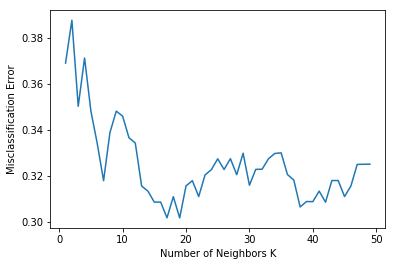

```
The error at optimal k is 0.315630
```

```python
# will find the optimal k to have the best score with a 10-fold
# cross validation
k_list = list(range(1, 50))

scores = []
for k in k_list:
    neigh = KNeighborsClassifier(n_neighbors=k)
    # fitting the model
    neigh.fit(X_train, y_train)
    # using the model against the test data now
    knn_predict_romance = neigh.predict(X_test)
    # finding how well the model did
    score = cross_val_score(neigh, X_test, y_test,
                            cv=10, scoring='accuracy')
    scores.append(score.mean()) # append the score to the list

# finding misclassification error
error = [1 - x for x in scores]

# determining best k
optimalk = k_list[error.index(min(error))]
print "The optimal number of neighbors is %d" % optimalk
error_k = error[optimalk]

plt.plot(k_list, error)
plt.xlabel('Number of Neighbors K')
plt.ylabel('Misclassification Error')
plt.show()
print "The error at optimal k is %f" % error_k
```

### an error of 31-32% isn't too bad, time to compare it with logistic regression though.

## binary logistic regression model

```python
# logistic regression: Y = romance
variables = ['rating', 'user_amount', 'ep_count',
             'review_amount', 'member_amount', 'actor_rating']
# True = 1; False = 0
y = drama_df['romance'].map(lambda x: int(x))

# creating testing & training data
X_train, X_test, y_train, y_test = train_test_split(
    drama_df[variables], y, test_size=0.3, random_state=1)

logitreg = sm.Logit(y_train, X_train).fit()
logitreg.summary()
```

```
Optimization terminated successfully.
         Current function value: 0.514193
         Iterations 6
```

Logit Regression Results

| Dep. Variable: | romance | No. Observations: | 996 |
| --- | --- | --- | --- |
| Model: | Logit | Df Residuals: | 990 |
| Method: | MLE | Df Model: | 5 |
| Date: | Thu, 30 Nov 2017 | Pseudo R-squ.: | 0.1124 |
| Time: | 14:10:55 | Log-Likelihood: | -512.14 |
| converged: | True | LL-Null: | -576.99 |
|  |  | LLR p-value: | 2.752e-26 |

|  | coef | std err | z | P>\|z\| | [0.025 | 0.975] |
| --- | --- | --- | --- | --- | --- | --- |
| rating | -0.3195 | 0.067 | -4.779 | 0.000 | -0.451 | -0.188 |
| user_amount | 0.2458 | 0.083 | 2.960 | 0.003 | 0.083 | 0.409 |
| ep_count | 0.3340 | 0.073 | 4.549 | 0.000 | 0.190 | 0.478 |
| review_amount | 0.0692 | 0.113 | 0.613 | 0.540 | -0.152 | 0.290 |
| member_amount | 0.0309 | 0.119 | 0.260 | 0.795 | -0.202 | 0.264 |
| actor_rating | 0.1909 | 0.077 | 2.476 | 0.013 | 0.040 | 0.342 |

### all values are below .05 besides review_amount and member_amount, so i'll remove them to see what happens

```python
# logistic regression: Y = romance
variables = ['rating', 'user_amount', 'ep_count', 'actor_rating']
# True = 1; False = 0
y = drama_df['romance'].map(lambda x: int(x))

# creating testing & training data
X_train, X_test, y_train, y_test = train_test_split(
    drama_df[variables], y, test_size=0.3, random_state=1)

logitreg = sm.Logit(y_train, X_train).fit()
logitreg.summary()
```

```
Optimization terminated successfully.
         Current function value: 0.514466
         Iterations 6
```

Logit Regression Results

| Dep. Variable: | romance | No. Observations: | 996 |
| --- | --- | --- | --- |
| Model: | Logit | Df Residuals: | 992 |
| Method: | MLE | Df Model: | 3 |
| Date: | Thu, 30 Nov 2017 | Pseudo R-squ.: | 0.1119 |
| Time: | 14:10:55 | Log-Likelihood: | -512.41 |
| converged: | True | LL-Null: | -576.99 |
|  |  | LLR p-value: | 8.212e-28 |

|  | coef | std err | z | P>\|z\| | [0.025 | 0.975] |
| --- | --- | --- | --- | --- | --- | --- |
| rating | -0.3144 | 0.051 | -6.204 | 0.000 | -0.414 | -0.215 |
| user_amount | 0.2884 | 0.040 | 7.224 | 0.000 | 0.210 | 0.367 |
| ep_count | 0.3261 | 0.073 | 4.497 | 0.000 | 0.184 | 0.468 |
| actor_rating | 0.2034 | 0.072 | 2.818 | 0.005 | 0.062 | 0.345 |

### p-values look good

```python
# odds ratios
numpy.exp(logitreg.params)
```

```
rating          0.730241
user_amount     1.334342
ep_count        1.385544
actor_rating    1.225524
dtype: float64
```

```python
# finding out how well the model did
logit_predict_romance = logitreg.predict(X_test)
logit_predict_romance = logit_predict_romance.map(
    lambda x: round(x))

logit_score = float(float(sum(logit_predict_romance == y_test))/
                    float(len(y_test)))
1 - logit_score # find the error
```

```
0.30841121495327106
```

### when comparing the models (knn vs. logistic regression), logit seems to do better in terms of accuracy. overall though, both models have a 30-31% error rate, meaning that 70% of the time, they are accurate in their predictions when it comes to estimating whether or not a certain drama is a romance one or not.